# Machine Learning Engineer Nanodegree

## Model Evaluation & Validation

## Project 1: Predicting Boston Housing Prices

Welcome to the first project of the Machine Learning Engineer Nanodegree! In this notebook, some template code has already been written. You will need to implement additional functionality to successfully answer all of the questions for this project. Unless it is requested, do not modify any of the code that has already been included. In this template code, there are four sections which you must complete to successfully produce a prediction with your model. Each section where you will write code is preceded by a **STEP X** header with comments describing what must be done. Please read the instructions carefully!

In addition to implementing code, there will be questions that you must answer that relate to the project and your implementation. Each section where you will answer a question is preceded by a **QUESTION X** header. Be sure that you have carefully read each question and provide thorough answers in the text boxes that begin with "**Answer:**". Your project submission will be evaluated based on your answers to each of the questions.

A description of the dataset can be found [here](https://archive.ics.uci.edu/ml/datasets/Housing), which is provided by the **UCI Machine Learning Repository**.

# Getting Started

To familiarize yourself with an iPython Notebook, **try double clicking on this cell**. You will notice that the text changes so that all the formatting is removed. This allows you to make edits to the block of text you see here. This block of text (and mostly anything that's not code) is written using [Markdown](http://daringfireball.net/projects/markdown/syntax), which is a way to format text using headers, links, italics, and many other options! Whether you're editing a Markdown text block or a code block (like the one below), you can use the keyboard shortcut **Shift + Enter** or **Shift + Return** to execute the code or text block. In this case, it will show the formatted text.

Let's start by setting up some code we will need to get the rest of the project up and running. Use the keyboard shortcut mentioned above on the following code block to execute it. Alternatively, depending on your iPython Notebook program, you can press the **Play** button in the hotbar. You'll know the code block executes successfully if the message *"Boston Housing dataset loaded successfully!"* is printed.

```python
# Importing a few necessary libraries
import numpy as np
import matplotlib.pyplot as pl
from sklearn import datasets
from sklearn.tree import DecisionTreeRegressor

# Make matplotlib show our plots inline (nicely formatted in the notebook)
%matplotlib inline

# Create our client's feature set for which we will be predicting a selling price
CLIENT_FEATURES = [[11.95, 0.00, 18.100, 0, 0.6590, 5.6090, 90.00, 1.385, 24, 680.0, 20.20, 332.09, 12.13]]

# Load the Boston Housing dataset into the city_data variable
city_data = datasets.load_boston()

# Initialize the housing prices and housing features
housing_prices = city_data.target
housing_features = city_data.data

print("Boston Housing dataset loaded successfully!")
```

```
Boston Housing dataset loaded successfully!
```

# Statistical Analysis and Data Exploration

In this first section of the project, you will quickly investigate a few basic statistics about the dataset you are working with. In addition, you'll look at the client's feature set in `CLIENT_FEATURES` and see how this particular sample relates to the features of the dataset. Familiarizing yourself with the data through an explorative process is a fundamental practice to help you better understand your results.

## Step 1

In the code block below, use the imported `numpy` library to calculate the requested statistics. You will need to replace each `None` you find with the appropriate `numpy` coding for the proper statistic to be printed. Be sure to execute the code block each time to test if your implementation is working successfully. The print statements will show the statistics you calculate!

```python
# Number of houses in the dataset
total_houses = np.asarray(housing_prices).shape[0]

# Number of features in the dataset
total_features = np.asarray(housing_features).shape[1]

# Minimum housing value in the dataset
minimum_price = np.amin(np.asarray(housing_prices))

# Maximum housing value in the dataset
maximum_price = np.amax(np.asarray(housing_prices))

# Mean house value of the dataset
mean_price = np.mean(np.asarray(housing_prices))

# Median house value of the dataset
median_price = np.median(np.asarray(housing_prices))

# Standard deviation of housing values of the dataset
std_dev = np.std(np.asarray(housing_prices))

# Show the calculated statistics
print("Boston Housing dataset statistics (in $1000's):\n")
print("Total number of houses:", total_houses)
print("Total number of features:", total_features)
print("Minimum house price:", minimum_price)
print("Maximum house price:", maximum_price)
print("Mean house price: {0:.3f}".format(mean_price))
print("Median house price:", median_price)
print("Standard deviation of house price: {0:.3f}".format(std_dev))

print(np.percentile(np.asarray(housing_prices), .99))

# correlation coefficients with label for each feature
for i in range(np.asarray(housing_features).shape[1]):
    print(i, np.amin(np.corrcoef(np.asarray(housing_features)[:,i], np.asarray(housing_prices))))
```

```
Boston Housing dataset statistics (in $1000's):

Total number of houses: 506
Total number of features: 13
Minimum house price: 5.0
Maximum house price: 50.0
Mean house price: 22.533
Median house price: 21.2
Standard deviation of house price: 9.188
7.0
0 -0.385831689884
1 0.360445342451
2 -0.483725160028
3 0.17526017719
4 -0.427320772373
5 0.695359947072
6 -0.376954565005
7 0.249928734086
8 -0.38162623064
9 -0.468535933568
10 -0.507786685538
11 0.333460819657
12 -0.737662726174
```

## Question 1

As a reminder, you can view a description of the Boston Housing dataset [here](https://archive.ics.uci.edu/ml/datasets/Housing), where you can find the different features under **Attribute Information**. The `MEDV` attribute relates to the values stored in our `housing_prices` variable, so we do not consider that a feature of the data.

*Of the features available for each data point, choose three that you feel are significant and give a brief description for each of what they measure.*

Remember, you can **double click the text box below** to add your answer!

**Answer:** a quick measure of correlation (see above code fragment) shows that the following possess explanatory power:

1) average number of rooms per dwelling (RM); positively correlated; indicating the sheer size of the house, given that room sizes are in general similar across houses, raises its price

2) pupil-teacher ratio by town (PTRATIO); negatively correlated; indicating that a lower number of pupils per teacher in the neighbouring schools of a house is raising its price

3) % lower status of the population (LSTAT); negatively correlated; indicating that a generally low status of population in the surrounding of a house (high % of lower status) is lowering its price

## Question 2

*Using your client's feature set `CLIENT_FEATURES`, which values correspond with the features you've chosen above?*  
**Hint:** Run the code block below to see the client's data.

```python
print(CLIENT_FEATURES)
print(np.asarray(CLIENT_FEATURES)[:,[5,10,12]])
```

```
[[11.95, 0.0, 18.1, 0, 0.659, 5.609, 90.0, 1.385, 24, 680.0, 20.2, 332.09, 12.13]]
[[  5.609  20.2    12.13 ]]
```

**Answer:** The corresponding values are:

1) RM: 5.609

2) PTRATIO: 20.2

3) LSTAT: 12.13

# Evaluating Model Performance

In this second section of the project, you will begin to develop the tools necessary for a model to make a prediction. Being able to accurately evaluate each model's performance through the use of these tools helps to greatly reinforce the confidence in your predictions.

## Step 2

In the code block below, you will need to implement code so that the `shuffle_split_data` function does the following:

- Randomly shuffle the input data `X` and target labels (housing values) `y`.
- Split the data into training and testing subsets, holding 30% of the data for testing.

If you use any functions not already acessible from the imported libraries above, remember to include your import statement below as well!  
Ensure that you have executed the code block once you are done. You'll know the `shuffle_split_data` function is working if the statement *"Successfully shuffled and split the data!"* is printed.

```python
# Put any import statements you need for this code block here

def shuffle_split_data(X, y):
    """ Shuffles and splits data into 70% training and 30% testing subsets,
        then returns the training and testing subsets. """

    ## Shuffle and split the data

    # Determine training set size
    training_set_size = round(0.7*total_houses)
    # Stack features and labels in order to preserve integrity
    fullset = np.column_stack((np.asarray(housing_features), np.asarray(housing_prices)))
    # Shuffle stack
    np.random.shuffle(fullset)
    # Get training and test sets
    full_train = []
    full_test = []
    for i in range(total_houses):
        if(i < training_set_size):
            row_train = []
            for item in fullset[i]:
               row_train.append(item)
            full_train.append(row_train)
        else:
            row_test = []
            for item in fullset[i]:
               row_test.append(item)
            full_test.append(row_test)
    # split full sets into features and target again
    feature_range = np.arange(0,13)
    X_train = np.asarray(full_train)[:,feature_range]
    y_train = np.asarray(full_train)[:,13]
    X_test = np.asarray(full_test)[:,feature_range]
    y_test = np.asarray(full_test)[:,13]

    # Return the training and testing data subsets
    return X_train, y_train, X_test, y_test


# Test shuffle_split_data
try:
    X_train, y_train, X_test, y_test = shuffle_split_data(housing_features, housing_prices)
    print("Successfully shuffled and split the data!")
except:
    print("Something went wrong with shuffling and splitting the data.")
```

```
Successfully shuffled and split the data!
```

## Question 3

*Why do we split the data into training and testing subsets for our model?*

**Answer:** If we used the full data as training set, we would eventually have an idea on how well the model is fitting to this specific data set, but not on how well it performs onto independent data unknown to the model. But the latter is pivotal, since it is all about prediction. The test set is a simulation of fresh data, and thus we measure crucial performance indicators on the test set. Like this, we make sure that the model is generalizing well to unknown data. Any model overly adapted to the training set will eventually reveal a weak fit on the test data. On the other hand, a sufficiently large training set is also required, in order to give the model the chance to grasp the patterns in the data. By separating training and test, we want to prevent "leakage", i.e. the model making predictions on data it has already seen.

## Step 3

In the code block below, you will need to implement code so that the `performance_metric` function does the following:

- Perform a total error calculation between the true values of the `y` labels `y_true` and the predicted values of the `y` labels `y_predict`.

You will need to first choose an appropriate performance metric for this problem. See [the sklearn metrics documentation](http://scikit-learn.org/stable/modules/classes.html#sklearn-metrics-metrics) to view a list of available metric functions. **Hint:** Look at the question below to see a list of the metrics that were covered in the supporting course for this project.

Once you have determined which metric you will use, remember to include the necessary import statement as well!  
Ensure that you have executed the code block once you are done. You'll know the `performance_metric` function is working if the statement *"Successfully performed a metric calculation!"* is printed.

```python
# Put any import statements you need for this code block here
from sklearn.metrics import mean_squared_error

def performance_metric(y_true, y_predict):
    """ Calculates and returns the total error between true and predicted values
        based on a performance metric chosen by the student. """

    # Ordinary Least Squares
    #error = sum(np.power(np.subtract(y_true, y_predict), 2))/y_true.shape[0]
    error = mean_squared_error(y_true, y_predict)
    return error

# Test performance_metric
try:
    total_error = performance_metric(y_train, y_train)
    print("Successfully performed a metric calculation!")
except:
    print("Something went wrong with performing a metric calculation.")
```

```
Successfully performed a metric calculation!
```

## Question 4

*Which performance metric below did you find was most appropriate for predicting housing prices and analyzing the total error. Why?*

- *Accuracy*
- *Precision*
- *Recall*
- *F1 Score*
- *Mean Squared Error (MSE)*
- *Mean Absolute Error (MAE)*

**Answer:** Since we are facing a regression and not a classification problem, I had the choice between MSE and MAE. I chose MSE since I generally like the idea of emphasizing larger errors over smaller errors, and since it is differentiable. In general, I think both MSE and MAE are suited for the problem

## Step 4 (Final Step)

In the code block below, you will need to implement code so that the `fit_model` function does the following:

- Create a scoring function using the same performance metric as in **Step 2**. See the [sklearn `make_scorer` documentation](http://scikit-learn.org/stable/modules/generated/sklearn.metrics.make_scorer.html).
- Build a GridSearchCV object using `regressor`, `parameters`, and `scoring_function`. See the [sklearn documentation on GridSearchCV](http://scikit-learn.org/stable/modules/generated/sklearn.grid_search.GridSearchCV.html).

When building the scoring function and GridSearchCV object, *be sure that you read the parameters documentation thoroughly.* It is not always the case that a default parameter for a function is the appropriate setting for the problem you are working on.

Since you are using `sklearn` functions, remember to include the necessary import statements below as well!  
Ensure that you have executed the code block once you are done. You'll know the `fit_model` function is working if the statement *"Successfully fit a model to the data!"* is printed.

```python
# Put any import statements you need for this code block
from sklearn.tree import DecisionTreeRegressor
from sklearn.metrics import mean_squared_error, make_scorer
from sklearn.grid_search import GridSearchCV

def fit_model(X, y):
    """ Tunes a decision tree regressor model using GridSearchCV on the input data X
        and target labels y and returns this optimal model. """

    # Create a decision tree regressor object
    regressor = DecisionTreeRegressor()

    # Set up the parameters we wish to tune
    parameters = {'max_depth':(1,2,3,4,5,6,7,8,9,10)}

    # Make an appropriate scoring function
    scoring_function = make_scorer(performance_metric, greater_is_better=False)

    # Make the GridSearchCV object
    reg = GridSearchCV(regressor, param_grid=parameters, scoring=scoring_function)

    # Fit the learner to the data to obtain the optimal model with tuned parameters
    reg.fit(X, y)

    # Return the optimal model
    return reg.best_estimator_


# Test fit_model on entire dataset
try:
    reg = fit_model(housing_features, housing_prices)
    print("Successfully fit a model!")
except:
    print("Something went wrong with fitting a model.")
```

```
Successfully fit a model!
```

## Question 5

*What is the grid search algorithm and when is it applicable?*

**Answer:** V2 -- The grid search algorithm does the job of optimizing the parameter value for a model. In contrast to the model itself, which focuses on the available training data and tries to minimize a loss function or maximize a gain function on it, grid search aims to ensure that the model does not overfit the training data, but in contrast generalizes well on the test data. A grid search algorithm runs exhaustively over a manually confined set of model parameter values. Typically, one measures the outcomes of the so created models by looking at the performance of the models on the test set. Often, this is done by additionally applying cross validation, and subsequently using the average test set performance as the performance metric.

Grid search is useful when there are multiple parametrization options on how to tune a model. For the here used tree, the parameter is the depth of the tree, and one must choose an optimal parameter option (max_depth) to prune the tree.

## Question 6

*What is cross-validation, and how is it performed on a model? Why would cross-validation be helpful when using grid search?*

**Answer:** By dividing the sample into a training and a test set, we avoid the "leakage" problem, as described above. However, the division of the sample into two sets is random and arbitrary. So, a test set could by chance contain a completely different pattern than the training set. In plus, we want to maximize the training set size in order to get the best learning result, and at the same time maximize the test set size in order to get the best validation. Both issues are addressed by cross validation: Instead of only one split, we split the data in k equally sized sets (k-1 splits). We run then k independent measuring experiments, each time with k-1 sample buckets as training set, and 1 bucket as test set. The average score/loss function over all k test sets is the performance metric for the model.

V2 -- Since grid search is aimed at preventing overfitting, it goes well together with cross validation: The grid search performance metric is measured on the test set for a specific parameter value. By running k independent experiments with one chosen model parameter value, one ensures that the guiding metric in grid search is not the product of one arbitrary split between training and test set, but the average of k-1 splits.

V2 -- Example: if by chance training and test set are very similar, an overfitted model will perform well on the test set as well, and thus will leave the grid search algorithm in the belief that the model is NOT overfitted. Repeated measures over different test sets will prevent such deception.

# Checkpoint!

You have now successfully completed your last code implementation section. Pat yourself on the back! All of your functions written above will be executed in the remaining sections below, and questions will be asked about various results for you to analyze. To prepare the **Analysis** and **Prediction** sections, you will need to intialize the two functions below. Remember, there's no need to implement any more code, so sit back and execute the code blocks! Some code comments are provided if you find yourself interested in the functionality.

```python
def learning_curves(X_train, y_train, X_test, y_test):
    """ Calculates the performance of several models with varying sizes of training data.
        The learning and testing error rates for each model are then plotted. """

    print("Creating learning curve graphs for max_depths of 1, 3, 6, and 10. . .")

    # Create the figure window
    fig = pl.figure(figsize=(10,8))

    # We will vary the training set size so that we have 50 different sizes
    sizes = np.rint(np.linspace(1, len(X_train), 50)).astype(int)
    train_err = np.zeros(len(sizes))
    test_err = np.zeros(len(sizes))

    # Create four different models based on max_depth
    for k, depth in enumerate([1,3,6,10]):

        for i, s in enumerate(sizes):

            # Setup a decision tree regressor so that it learns a tree with max_depth = depth
            regressor = DecisionTreeRegressor(max_depth = depth)

            # Fit the learner to the training data
            regressor.fit(X_train[:s], y_train[:s])

            # Find the performance on the training set
            train_err[i] = performance_metric(y_train[:s], regressor.predict(X_train[:s]))

            # Find the performance on the testing set
            test_err[i] = performance_metric(y_test, regressor.predict(X_test))

        # Subplot the learning curve graph
        ax = fig.add_subplot(2, 2, k+1)
        ax.plot(sizes, test_err, lw = 2, label = 'Testing Error')
        ax.plot(sizes, train_err, lw = 2, label = 'Training Error')
        ax.legend()
        ax.set_title('max_depth = %s'%(depth))
        ax.set_xlabel('Number of Data Points in Training Set')
        ax.set_ylabel('Total Error')
        ax.set_xlim([0, len(X_train)])

    # Visual aesthetics
    fig.suptitle('Decision Tree Regressor Learning Performances', fontsize=18, y=1.03)
    fig.tight_layout()
    fig.show()
```

```python
def model_complexity(X_train, y_train, X_test, y_test):
    """ Calculates the performance of the model as model complexity increases.
        The learning and testing errors rates are then plotted. """

    print("Creating a model complexity graph. . . ")

    # We will vary the max_depth of a decision tree model from 1 to 14
    max_depth = np.arange(1, 14)
    train_err = np.zeros(len(max_depth))
    test_err = np.zeros(len(max_depth))

    for i, d in enumerate(max_depth):
        # Setup a Decision Tree Regressor so that it learns a tree with depth d
        regressor = DecisionTreeRegressor(max_depth = d)

        # Fit the learner to the training data
        regressor.fit(X_train, y_train)

        # Find the performance on the training set
        train_err[i] = performance_metric(y_train, regressor.predict(X_train))

        # Find the performance on the testing set
        test_err[i] = performance_metric(y_test, regressor.predict(X_test))

    # Plot the model complexity graph
    pl.figure(figsize=(7, 5))
    pl.title('Decision Tree Regressor Complexity Performance')
    pl.plot(max_depth, test_err, lw=2, label = 'Testing Error')
    pl.plot(max_depth, train_err, lw=2, label = 'Training Error')
    pl.legend()
    pl.xlabel('Maximum Depth')
    pl.ylabel('Total Error')
    pl.show()
```

# Analyzing Model Performance

In this third section of the project, you'll take a look at several models' learning and testing error rates on various subsets of training data. Additionally, you'll investigate one particular algorithm with an increasing `max_depth` parameter on the full training set to observe how model complexity affects learning and testing errors. Graphing your model's performance based on varying criteria can be beneficial in the analysis process, such as visualizing behavior that may not have been apparent from the results alone.

```
Creating learning curve graphs for max_depths of 1, 3, 6, and 10. . .
```

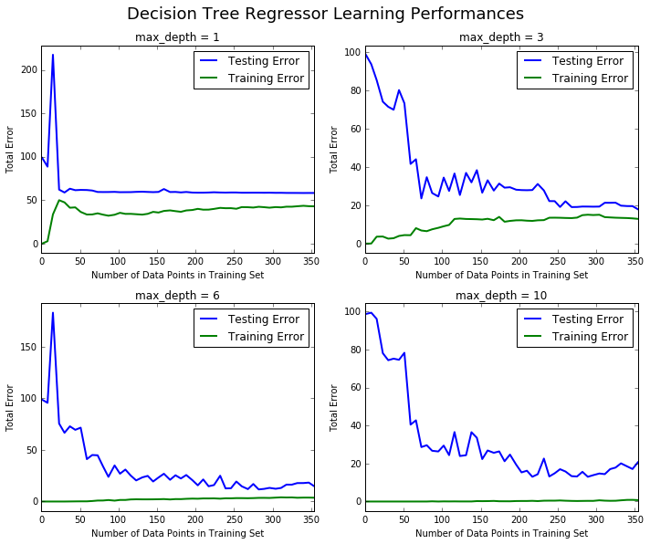

```python
learning_curves(X_train, y_train, X_test, y_test)
```

## Question 7

*Choose one of the learning curve graphs that are created above. What is the max depth for the chosen model? As the size of the training set increases, what happens to the training error? What happens to the testing error?*

**Answer:** I look at the model with max_depth = 6.

The training error increases very slightly with increasing set size on a generally very moderate level (compared to models with less max_depth). As expected, the bias generally decreases with increasing model complexity, and generally the underfitting (if present as in models max_depth = 1 and max_depth = 3) becomes more obvious, the more data is available in the training set.

Back to model max_depth = 6: the error of the test set decreases up to where the test set size is so small, that probably there are too few data points to obtain a stable test error. The test error levels off at around 20, which is about the level of model max_depth = 3, but with more variance than the one from max_depth = 3.

All together, max_depth = 3 seems to underfit a bit, max_depth = 6 suffers more from high variance in the test set. This is an indication that the optimal max_depth lies between max_depth = 3 and max_depth = 6.

## Question 8

*Look at the learning curve graphs for the model with a max depth of 1 and a max depth of 10. When the model is using the full training set, does it suffer from high bias or high variance when the max depth is 1? What about when the max depth is 10?*

**Answer:** The model suffers from high bias when max_depth = 1, it suffers from high variance when max_depth = 10.

V2 -- The high bias in model max_depth = 1 is already reached at small training set sizes and does not vanish even with massive size increase. There is clearly a misconception of the underlying data structure present. The level of the training set error is not reached by any other model. On the other hand, the test set shows no error variance at all after some point of increasing the training set size.

With a complex model with parameter value 10, one cleary sees that the training set data structure is extremely well adapted by the model, even already at very small training set sizes. There is hence no high bias present. In the light of the bias-variance-tradeoff, we then observe the very unstable test set error at high level, indicating indeed that the model suffers from high variance in the test set.

```
Creating a model complexity graph. . .
```

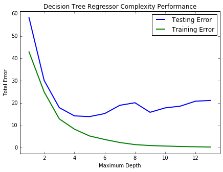

```python
model_complexity(X_train, y_train, X_test, y_test)
```

## Question 9

*From the model complexity graph above, describe the training and testing errors as the max depth increases. Based on your interpretation of the graph, which max depth results in a model that best generalizes the dataset? Why?*

**Answer:** As the complexity of the model increases, the training set error decreases with decreasing slope: Might the first steps of increasing complexity result in a significantly lowered bias, this gain decreases over-proportionally with additional complexity.

The test error shapes a U-function with increasing complexity: the first steps of increasing complexity result in a significantly lowered test error, but a some point the overfitting is exposed: the test error increases with increasing complexity, i.e. the model is adapting too much to the training data and shows poor results on independent test data.

To trade-off bias and variance, I argue that a max_depth around 4 or 5 is the best choice: The test error is at its lowest level (the model generalizes well) and the training error is close enough to the lowest possible level (the model is reasonably unbiased).

V2 -- I will eventually pick the model with max_depth = 4. This is the simplest model at which the lowest (or close to lowest) test set error is reached.

# Model Prediction

In this final section of the project, you will make a prediction on the client's feature set using an optimized model from `fit_model`. When applying grid search along with cross-validation to optimize your model, it would typically be performed and validated on a training set and subsequently evaluated on a **dedicated test set**. In this project, the optimization below is performed on the *entire dataset* (as opposed to the training set you made above) due to the many outliers in the data. Using the entire dataset for training provides for a less volatile prediction at the expense of not testing your model's performance.

*To answer the following questions, it is recommended that you run the code blocks several times and use the median or mean value of the results.*

## Question 10

*Using grid search on the entire dataset, what is the optimal `max_depth` parameter for your model? How does this result compare to your intial intuition?*  
**Hint:** Run the code block below to see the max depth produced by your optimized model.

```python
print("Final model has an optimal max_depth parameter of", reg.get_params()['max_depth'])
```

```
Final model has an optimal max_depth parameter of 4
```

**Answer:** The optimal max_depth is 4. This fits rather well with my intuition as described above. From looking only at the learning curves, I would have chosen a model around max_depth = 5 to avoid the high bias displayed in model max_depth = 3 (by looking at it again, I should have noted the remarkably lower variance in model max_depth = 3, which actually point more to a max_depth of 4). The model complexity graph would have allowed for depth 5 too, but shows also that the test error is about the same with max_depth = 4. I am comfortable with this pruning.

## Question 11

*With your parameter-tuned model, what is the best selling price for your client's home? How does this selling price compare to the basic statistics you calculated on the dataset?*

**Hint:** Run the code block below to have your parameter-tuned model make a prediction on the client's home.

```python
sale_price = reg.predict(CLIENT_FEATURES)
print("Predicted value of client's home: {0:.3f}".format(sale_price[0]))
```

```
Predicted value of client's home: 21.630
```

**Answer:** The predicted value is 21.63. This is both close to the average price (22.5) as well as the median price (21.2).

## Question 12 (Final Question):

*In a few sentences, discuss whether you would use this model or not to predict the selling price of future clients' homes in the Greater Boston area.*

**Answer:** I generally find that the model shows a comprehensible pattern of both training and test error in the light of model complexity and set sizes, that is: my intuion is aligned with the model proposal on how to prune the decision tree (I ran two runs). This gives me confidence that this is a suitable model. What is missing here is to cross-check my initial idea about the explanatory power of single features. If this is aligned, I definitely would use the model.